# New York City Bike Análisis

Costela Guijosa, Jose Luis

Reyes López, Marta

Rodríguez Dueñas, Aitor

Sánchez Jiménez, Manuel

Febrero de 2025

## 1. Introducción

Este proyecto ha sido realizado por el Equipo 2. La comunicación entre los miembros del grupo se ha llevado a cabo a través de reuniones y mensajes en Discord. La gestión del proyecto se ha realizado mediante un repositorio en GitHub. Se eligió R como lenguaje de programación, ya que consideramos que se alineaba mejor con la asignatura, dado que todos los conocimientos técnicos impartidos han sido en este lenguaje.

## 2. Descripción del Dominio

El proyecto se centra en el análisis de datos de **Citi Bike**, un sistema de bicicletas compartidas en la ciudad de Nueva York. Citi Bike permite a los usuarios alquilar bicicletas en diferentes estaciones distribuidas por la ciudad. Más información sobre el servicio está disponible en su página web oficial: [Citi Bike NYC](https://citibikenyc.com/homepage).

El estudio de los datos de Citi Bike es relevante porque refleja **patrones de movilidad urbana** en una de las ciudades más transitadas del mundo. Como **estudiantes de Data Science**, este análisis nos permite aplicar técnicas de **procesamiento, limpieza y modelado de datos** a un caso real con un gran impacto en la planificación urbana y la sostenibilidad.

Además, el sector de la **micromovilidad** está en crecimiento, y comprender el comportamiento de los usuarios puede aportar **insights valiosos** para mejorar la eficiencia del sistema y fomentar el uso del **transporte sostenible** en otras ciudades.

## 3. Descripción del Dataset

Los datos están organizados por meses y comprimidos en archivos ZIP. La estrategia inicial para importar y procesar esta información fue descomprimir y combinar todos los datos en orden cronológico. Sin embargo, surgió un primer obstáculo: a partir de algunos meses de 2017 y/o 2018, los nombres de las columnas cambiaron (aunque el formato era el mismo, había diferencias en mayúsculas y minúsculas, por ejemplo). Al unificar los datos, algunos tipos de datos no coincidían y se generaban duplicaciones de variables.

Para solucionar este problema, se decidió **unificar los nombres de todas las columnas en minúsculas**. Una vez normalizados los datos, se organizó cada año en archivos CSV individuales y se almacenaron en una carpeta denominada `"combined"`, donde se prepararon para su procesamiento final. Para poder gestionar archivos de gran tamaño en GitHub, se utilizó **Git Large File Storage (Git LFS)**.

Este fue el código usado para compilar cada mes de cada año (estos compiler los obtuvimos de ChatGPT):

```r
cat("Buscando archivos en:", getwd(), "\n")
archivos_csv <- list.files(path = getwd(), pattern = "(?i)\.csv$", full.names = TRUE)
cat("Archivos encontrados:\n")
print(archivos_csv)

# Verificar si hay archivos CSV en la carpeta
if (length(archivos_csv) == 0) {
  stop("No se encontraron archivos CSV en la carpeta. Verifica la ruta o la extensión de los archivos.")
}

# Función para renombrar columnas
renombrar_columnas <- function(df) {
  colnames(df) <- c("tripduration", "starttime", "stoptime", "start.station.id",
                    "start.station.name", "start.station.latitude", "start.station.longitude",
                    "end.station.id", "end.station.name", "end.station.latitude", "end.station.longitude",
                    "bikeid", "usertype", "birth.year", "gender")
  return(df)
}

# Leer y combinar todos los archivos CSV
cat("Procesando archivos...\n")
df_combinado <- archivos_csv %>%
  lapply(function(archivo) {
    cat("Procesando:", archivo, "\n")
    df <- read_csv(archivo)
    renombrar_columnas(df)
  }) %>%
  bind_rows() %>%
  mutate(birth.year = as.numeric(birth.year))

# Obtener el año de los archivos y construir el nombre de salida
nombres_archivos <- basename(archivos_csv)
años_detectados <- unique(gsub(".*(\\d{4}).csv$", "\\1", nombres_archivos))
nombre_salida <- paste0("citibike_tripdata_combinado_", paste(años_detectados, collapse = "_"), ".csv")

# Guardar el dataset combinado
write_csv(df_combinado, nombre_salida)
cat("Proceso completado. Archivo guardado en", nombre_salida, "\n")
```

Este fragmento para combinarlos y crear el dataset desde el que partimos el proyecto:

```r
archivos_csv <- list.files(path = "data/combined", pattern = "(?i)\\.csv$", full.names = TRUE)
nombres_columnas <- c("tripduration", "starttime", "stoptime", "start.station.id",
                      "start.station.name", "start.station.latitude", "start.station.longitude",
                      "end.station.id", "end.station.name", "end.station.latitude",
                      "end.station.longitude", "bikeid", "usertype", "birth.year", "gender")


df_combinado <- archivos_csv %>%
  lapply(function(archivo) {
    cat("Procesando:", archivo, "\n")
    df_col <- read_csv(archivo, show_col_types = FALSE)
    colnames(df_col) <- nombres_columnas
    return(df_col)
  }) %>%
  bind_rows()

write_csv(df_combinado, "data/bike_data.csv")
```

El dataset final resultante se denomina **`bike_data.csv`** y tiene las siguientes características:

- **Tamaño del dataset:** 271 MB.
- **Número de filas y columnas:** 1.702.660 filas y 15 columnas.

## 4. Importación, limpieza y tratamiento

La importanción y generación del dataset a tratar se ha mostrado en el punto previo, a continuación se mostrarán los detalles, la limpieza y el tratamiento del mismo.

### 4.1. Descripción de las Variables del Dataset

1. **Trip Duration (seconds)**
   - Duración total del viaje en segundos.
2. **Start Time and Date**
   - Fecha y hora de inicio del viaje.
3. **Stop Time and Date**
   - Fecha y hora de finalización del viaje.
4. **Start Station ID**
   - Identificador único de la estación de inicio.
5. **Start Station Name**: - Nombre de la estación de inicio.
6. **Start Station Latitude**:
   - Latitud de la estación de inicio.
7. **Start Station Longitude**: - Longitud de la estación de inicio.
8. **End Station ID**
   - Identificador único de la estación de destino.
9. **End Station Name**
   - Nombre de la estación de destino.
10. **End Station Latitude**
    - Latitud de la estación de destino.
11. **End Station Longitude**
    - Longitud de la estación de destino.
12. **Bike ID**
    - Identificador único de la bicicleta utilizada en el viaje.
13. **User Type**
    - Tipo de usuario:
      - **Customer**: Usuario con pase de 24 horas o 3 días.
      - **Subscriber**: Miembro anual del servicio.
14. **Gender** - Género del usuario:
    - **0** = No disponible
    - **1** = Hombre
    - **2** = Mujer
15. **Year of Birth** - Año de nacimiento del usuario.

### 4.2. Tratamiento y Limpieza

Como primer paso en el proceso de preprocesamiento, se ha llevado a cabo un análisis preliminar para identificar la presencia de valores faltantes (NA) en el conjunto de datos permitiendo evaluar la calidad de los datos.

```r
df <- read.csv("data/bike_data.csv", stringsAsFactors = FALSE)
df %>% summarise_all(~ sum(is.na(.)))
```

```
##   tripduration starttime stoptime start.station.id start.station.name
## 1            0         0        0                0                  0
##   start.station.latitude start.station.longitude end.station.id
## 1                      0                       0              0
##   end.station.name end.station.latitude end.station.longitude bikeid usertype
## 1                0                    0                     0      0      497
##   birth.year gender
## 1      44242      0
```

Se ha identificado la presencia de 497 valores faltantes en la columna correspondiente al tipo de usuario (usertype). Para su tratamiento, se ha decidido asignarles la categoría ‘Customer’, bajo la suposición de que la ausencia de este dato sugiere que el usuario no está registrado y, por lo tanto, es un usuario esporádico. Además, preferimos tratar directamente con la edad del usuario mejor que con el año de nacimiento resulta más cómodo para el análisis a nuestro parecer, así pues en la columna correspondiente al año de nacimiento (birth.year), se ha detectado un total de 44,242 valores faltantes o nulos. Para su tratamiento, se ha calculado la edad (age) y luego en los valores vacíos se ha decidido ignorarlos ya que posiblemente sean Customer que no han puesto su edad o no se ha registrado correctamente. Adicionalmente hemos cambiado el formato del género a string siguiendo lo que pone en la propia web donde 0 = no definido, 1 = masculino y 2 = femenino.

```r
df <- df %>% mutate(usertype = ifelse(is.na(usertype), "Customer", usertype))
df <- df %>% mutate(age = ifelse(!is.na(birth.year), as.numeric(format(Sys.Date(), "%Y")) - birth.year, NA))
df <- df %>% mutate(gender = recode(gender, `0` = "NO_DEF", `1` = "Masculino", `2` = "Femenino"))
```

El siguiente paso en el preprocesamiento ha sido ajustar la escala de la duración del viaje, convirtiendo el tiempo de tripduration de segundos a minutos, dado que esta unidad resulta más adecuada para el análisis. Adicionalmente, se ha modificado el tipo de dato de los atributos starttime y stoptime, que originalmente estaban en formato de texto, convirtiéndolos a un tipo de dato de fecha mediante la librería lubridate. Este cambio facilita el manejo y análisis de los datos temporales, permitiendo realizar cálculos y agrupaciones con mayor precisión.

```r
df <- df %>% mutate(tripduration = tripduration / 60)
df$starttime <- ymd_hms(df$starttime)
df$stoptime <- ymd_hms(df$stoptime)
```

A continuación, se calculará la distancia recorrida entre las estaciones de inicio y fin utilizando la librería geosphere. Esta librería permite calcular la distancia entre dos puntos geográficos a partir de sus coordenadas de latitud y longitud.

```r
df$distance_km <- distHaversine(df[, c("start.station.longitude", "start.station.latitude")],
                                df[, c("end.station.longitude", "end.station.latitude")]) / 1000
df <- df %>% mutate(speed = (distance_km / tripduration)*60)
```

Por último, se ha detectado la presencia de ciertos registros en los que los valores de latitud y longitud son iguales a 0 para algunas estaciones de final del recorrido. Se ha procedido a identificar cuáles son las estaciones afectadas, con el fin de evaluar el impacto de estos datos atípicos en el análisis y determinar las acciones correctivas pertinentes.

```r
df_latlong0 <- df %>% filter(end.station.latitude == 0 | end.station.longitude == 0)

df_latlong0 %>%
  count(end.station.name) %>%
  arrange(desc(n))
```

```
##     end.station.name   n
## 1       WS Don't Use 536
## 2      JSQ Don't Use 248
## 3 Liberty State Park   2
## 4            Indiana   1
```

Se ha identificado que las siguientes estaciones presentan valores de latitud y longitud iguales a cero:

- “Indiana”
- “JSQ Don’t Use”
- “WS Don’t Use”
- “Liberty State Park”

Ante esta situación, se han definido dos estrategias de tratamiento. - Se ha decidido eliminar las estaciones “JSQ Don’t Use” y “WS Don’t Use”, ya que se intuye que corresponden a estaciones que se encuentran en deshuso o no son válidas en la actualidad. Además, tienen como valores de 0 para sus longitudes y latitudes respectivamente. - Se procederá a verificar si existen registros válidos para las estaciones ‘Indiana’ y ‘Liberty State Park’, con el objetivo de copiar sus valores correctos de latitud y longitud en aquellas instancias donde actualmente aparecen como cero. En caso de no encontrar ninguna instancia válida, se optará por eliminar estos registros, dado que representan un número reducido de casos, específicamente tres entre ambas estaciones.

```r
df_Ind_LSP <- df %>% filter(end.station.name %in% c("Indiana", "Liberty State Park")) # Se observa que en df_Ind_LSP no hay más instancias válidas, por lo que se procede a eliminar estas también

df_preprocesado <- df %>% filter(!(end.station.name %in% c("JSQ Don't Use", "WS Don't Use", "Indiana", "Liberty State Park")))
```

### 4.3. Descripción de las Variables del Dataset tras el Procesado:

El dataframe tras el procesado tiene:

- **Número de filas y columnas:** 1.701.873 filas y 18 columnas.

1. **Trip Duration**
   - Duración total del viaje en minutos - Clase: Numeric.
2. **Start Time and Date**
   - Fecha y hora de inicio del viaje - Clase: Timestamp.
3. **Stop Time and Date**
   - Fecha y hora de finalización del viaje - Clase: Timestamp.
4. **Start Station ID**
   - Identificador único de la estación de inicio - Clase: Numeric.
5. **Start Station Name**:
   - Nombre de la estación de inicio - Clase: Character.
6. **Start Station Latitude**:
   - Latitud de la estación de inicio - Clase: Numeric.
7. **Start Station Longitude**:
   - Longitud de la estación de inicio - Clase: Numeric.
8. **End Station ID**
   - Identificador único de la estación de destino - Clase: Numeric.
9. **End Station Name**
   - Nombre de la estación de destino - Clase: Character.
10. **End Station Latitude**
    - Latitud de la estación de destino - Clase: Numeric.
11. **End Station Longitude**
    - Longitud de la estación de destino - Clase: Numeric.
12. **Bike ID**
    - Identificador único de la bicicleta utilizada en el viaje - Clase: Numeric.
13. **User Type**
    - Tipo de usuario - Clase Character:
      - **Customer**: Usuario con pase de 24 horas o 3 días.
      - **Subscriber**: Miembro anual del servicio.
14. **Gender**
    - Género del usuario - Clase Character:
      - **NO_DEF**
      - **Masculino**
      - **Femenino**
15. **Year of Birth**
    - Año de nacimiento del usuario - Clase : Numeric.
16. **Age**
    - Edad del usuario - Clase : Numeric.
17. **Distance km**
    - Distancia reocrrida del viaje - Clase : Numeric.
18. **Speed**
    - Velocidad media en km/h del viaje - Clase : Numeric.

# 5. Preguntas grupales

## 5.1. PRIMERA PREGUNTA GRUPAL:

- **¿Cuando realizo el mantenimiento de las bicicletas?**

El análisis a realizar para responder a esta pregunta es identificar los períodos de menor uso de las bicicletas haciendo foco en como varía la demanda a lo largo del tiempo y considerando la distribución del uso en las distintas estaciones de la ciudad. Esto nos permitirá recomendar momentos y ubicaciones más adecuados para realizar el mantenimiento sin afectar significativamente la disponibilidad del servicio.

### 5.1.2. Justificación del método

Para asegurar un análisis completo y organizado del uso de las bicicletas, se ha utilizado un método que va de lo general a lo específico, permitiendo así una comprensión gradual de los patrones de demanda.

En primer lugar, se ha examinado la utilización de las bicicletas a nivel estacional, ya que factores climáticos y estacionales pueden impactar significativamente en la demanda. Luego, se ha desglosado el análisis por meses, lo que permite identificar cambios más detallados dentro de cada estación y posibles variaciones anuales.

Después, se ha evaluado el uso según los días de la semana y las franjas horarias, con el fin de detectar diferencias en la demanda entre días laborables y fines de semana, así como entre distintos momentos del día, como horas punta o períodos de menor afluencia.

Por último, se ha realizado un análisis espacial a través de un mapa de uso por estación, lo que permite identificar áreas con menor actividad y mejorar la planificación del mantenimiento sin afectar la disponibilidad del servicio.

Este enfoque gradual asegura una visión completa del comportamiento de la demanda y ayuda en la toma de decisiones bien fundamentadas para optimizar la gestión del sistema de bicicletas compartidas.

### 5.1.3. Gráficos globales y anuales

Extraer el mes y la estación del año La columna starttime indica la fecha y hora en que cada viaje comenzó. A partir de ella, extraemos el mes (month) y la estación (season). Las estaciones se definen de acuerdo con la meteorología estándar:

- Invierno: Diciembre, Enero, Febrero
- Primavera: Marzo, Abril, Mayo
- Verano: Junio, Julio, Agosto
- Otoño: Septiembre, Octubre, Noviembre

Se cuenta el número de viajes por mes y estación del año usando los datos de month y season para poder identificar la cantidad total de viajes en cada periodo. Con este recuento se define en una variable llamada total_rides para posteriormente sacar un histograma.

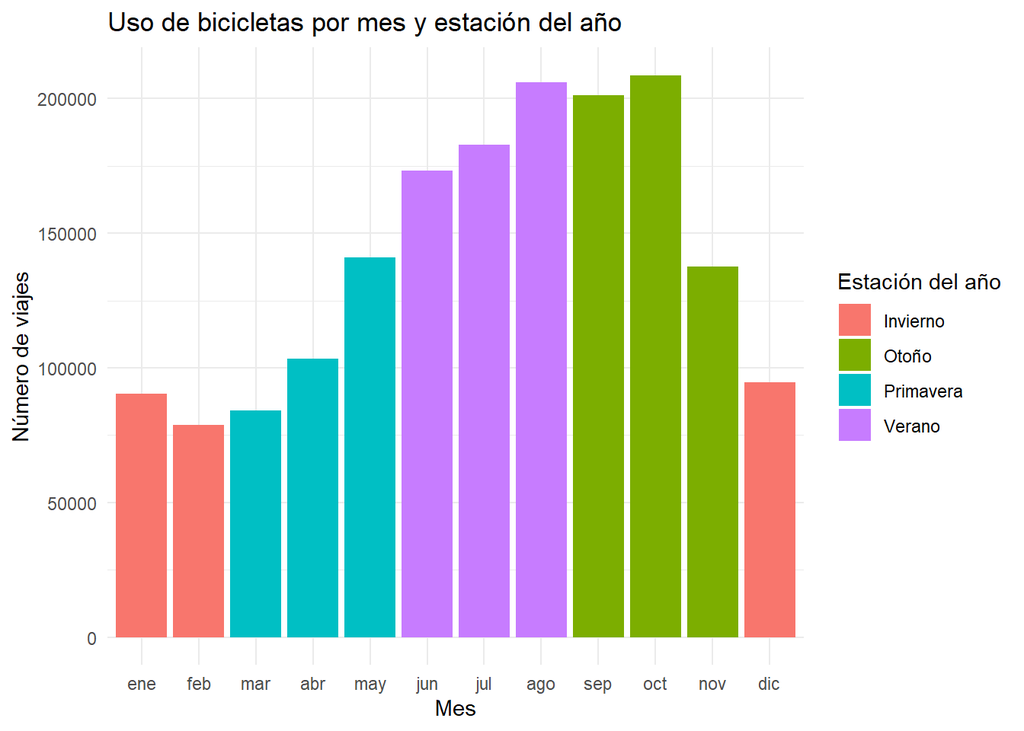

```r
df_mantenimiento <- df_preprocesado
df_mantenimiento$month <- month(df_mantenimiento$starttime, label = TRUE, abbr = TRUE)
df_mantenimiento$year <- year(df_mantenimiento$starttime)
df_mantenimiento <- df_mantenimiento %>% filter(!is.na(year) & year >= 2015 & year <= 2021)
df_mantenimiento$weekday <- wday(df_mantenimiento$starttime, label = TRUE, abbr = FALSE, week_start = 1)
df_mantenimiento$hour <- hour(df_mantenimiento$starttime)

df_mantenimiento$season <- case_when(
  df_mantenimiento$month %in% c("dic", "ene", "feb") ~ "Invierno",
  df_mantenimiento$month %in% c("mar", "abr", "may") ~ "Primavera",
  df_mantenimiento$month %in% c("jun", "jul", "ago") ~ "Verano",
  df_mantenimiento$month %in% c("sep", "oct", "nov") ~ "Otoño",
  TRUE ~ NA_character_
)

df_mantenimiento$time_period <- case_when(
  df_mantenimiento$hour >= 0 & df_mantenimiento$hour < 6  ~ "Madrugada",
  df_mantenimiento$hour >= 6 & df_mantenimiento$hour < 12 ~ "Mañana",
  df_mantenimiento$hour >= 12 & df_mantenimiento$hour < 18 ~ "Tarde",
  df_mantenimiento$hour >= 18 & df_mantenimiento$hour < 24 ~ "Noche",
  TRUE ~ NA_character_
)

df_mantenimiento <- df_mantenimiento %>% mutate(start_hour = hour(starttime))


df_mantenimiento_global <- df_mantenimiento %>%
  group_by(month, season) %>%
  summarise(total_rides = n(), .groups = 'drop')

ggplot(df_mantenimiento_global, aes(x = month, y = total_rides, fill = season)) +
  geom_bar(stat = "identity") +
  labs(title = "Uso de bicicletas por mes y estación del año",
       x = "Mes", y = "Número de viajes", fill= "Estación del año") +
  theme_minimal()
```

También se ha realizado el mismo análisis, pero separando por año. De esta manera podemos ver la evolución del uso de las bicicletas a lo largo de meses de los distintos años a evaluar y así poder comparar y sacar una conclusión más precisa sobre las tendencias de demanda y posibles cambios en los patrones de uso.

Para este análisis se ha tomado el año y el mes de columna startime y de la misma forma que en el anterior análisis se ha extraído las estaciones del año. Se hace un recuento por año de los usos según estación del año y mes y con este se genera un histograma.

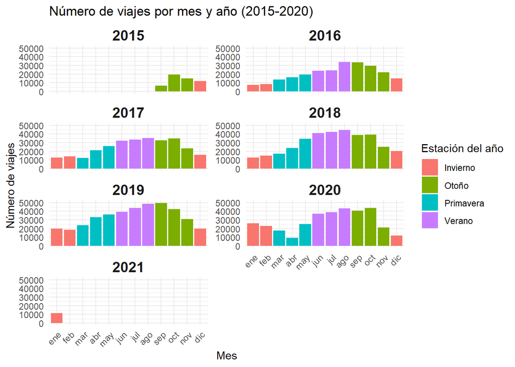

```r
df_counts_per_year <- df_mantenimiento %>%
  group_by(year, month, season) %>%
  summarise(total_rides = n(), .groups = 'drop')

ggplot(df_counts_per_year, aes(x = month, y = total_rides, fill = season)) +
  geom_bar(stat = "identity") +
  facet_wrap(~year, scales = "free_y", ncol = 2, strip.position = "top") +
  labs(title = "Número de viajes por mes y año (2015-2020)",
       x = "Mes", y = "Número de viajes", fill= "Estación del año") +
  ylim(0, 50000) +
  theme_minimal() +
  theme(axis.text.x = element_text(angle = 45, hjust = 1, vjust = 1),
        strip.text = element_text(size = 14, face = "bold"),
        panel.spacing = unit(0.5, "lines"),
        strip.placement = "outside")
```

### 5.1.4. Gráficos por día (semanal)

Extraer los días de la semana. Mediante la columna startime que contiene la fecha podemos calcular el día de la semana teniendo el mes y año creando la columna weekday. Con esta nueva columna se saca el recuento de uso de bicicletas por días de la semana y como anteriormente se genera un histograma para ilustrar los resultados.

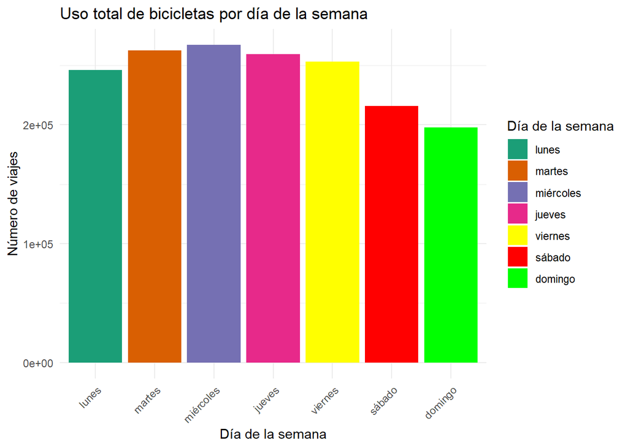

```r
df_counts_per_day <- df_mantenimiento %>%
  group_by(weekday) %>%
  summarise(total_rides = n(), .groups = 'drop')

df_counts_per_day$weekday <- factor(df_counts_per_day$weekday,
                                  levels = c("lunes", "martes", "miércoles", "jueves", "viernes", "sábado", "domingo"))

ggplot(df_counts_per_day, aes(x = weekday, y = total_rides, fill = weekday)) +
  geom_bar(stat = "identity") +
  labs(title = "Uso total de bicicletas por día de la semana",
       x = "Día de la semana", y = "Número de viajes", fill= "Día de la semana") +
  theme_minimal() +
  scale_fill_manual(values = c("#1b9e77", "#d95f02", "#7570b3", "#e7298a", "#ffff00", "#ff0000", "#00ff00")) +
  theme(axis.text.x = element_text(angle = 45, hjust = 1, vjust = 1))
```

### 5.1.5. Gráficos por horas

Extraer las franjas horarias. La columna startime contiene la hora por lo que se puede calcular la franja horaria que se definen de la siguiente manera:

- Madrugada: de 0 a 6 horas.
- Mañana: de 6 a 12 horas.
- Tarde: de 12 a 18 horas.
- Noche: de 18 a 24 horas.

Con las franjas horarias definidas se saca un recuento de los viajes por estación del año iniciados en cada una de las franjas para sacar un histograma y poder visualizar el análisis.

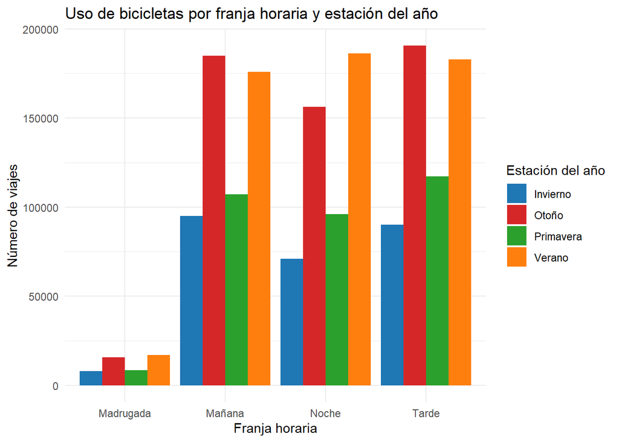

```r
df_time_periods <- df_mantenimiento %>%
  group_by(season, time_period) %>%
  summarise(total_rides = n(), .groups = 'drop')

ggplot(df_time_periods, aes(x = time_period, y = total_rides, fill = season)) +
  geom_bar(stat = "identity", position = "dodge") +
  labs(title = "Uso de bicicletas por franja horaria y estación del año",
       x = "Franja horaria", y = "Número de viajes", fill = "Estación del año") +
  theme_minimal() +
  scale_fill_manual(values = c("Invierno" = "#1f77b4", "Primavera" = "#2ca02c",
                               "Verano" = "#ff7f0e", "Otoño" = "#d62728"))
```

También se incluye para completar el análisis un histograma con el recuento de viajes iniciados por horas marcando en distinto color las horas donde más uso se ha dado a las bicicletas.

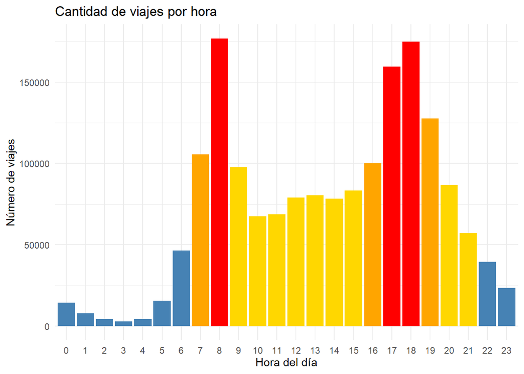

```r
hourly_usage <- df_mantenimiento %>%
  group_by(start_hour) %>%
  summarise(trips = n(), .groups = "drop") %>%
  arrange(start_hour)
hourly_usage$start_hour <- factor(hourly_usage$start_hour, levels = 0:23)


hourly_usage$color <- case_when(
  hourly_usage$trips > 150000 ~ "#FF0000",
  hourly_usage$trips > 100000 ~ "#FFA500",
  hourly_usage$trips > 50000  ~ "#FFD700",
  TRUE                        ~ "steelblue"
)

ggplot(hourly_usage, aes(x = start_hour, y = trips, fill = color)) +
  geom_col() +
  scale_fill_identity() +
  labs(title = "Cantidad de viajes por hora",
       x = "Hora del día",
       y = "Número de viajes") +
  theme_minimal() +
  scale_x_discrete(labels = 0:23) +
  theme(axis.text.x = element_text(angle = 0, vjust = 0.5))
```

### 5.1.6. Obtención de mapas.

Extracción de uso por estación. Para poder tener una mejor compresión sobre el recuento de usos de las estaciones se realizan mapas. Las estaciones se clasifican en cuartiles según su nivel de uso y se les asigna un color para una mejor compresión de los mapas.

```r
station_usage <- df_mantenimiento %>%
  group_by(start.station.id, start.station.name, start.station.latitude, start.station.longitude) %>%
  summarise(total_starts = n(), .groups = "drop") %>%
  arrange(desc(total_starts))

quartiles <- quantile(station_usage$total_starts, probs = c(0.25, 0.5, 0.75, 1))
station_usage$icon_color <- case_when(
  station_usage$total_starts <= quartiles[1] ~ "blue",
  station_usage$total_starts <= quartiles[2] ~ "green",
  station_usage$total_starts <= quartiles[3] ~ "orange",
  TRUE ~ "red")

bike_icon <- function(color) {
  awesomeIcons(
  icon = "bicycle",
  library = "fa",  # Esto nos lo ha prporcionado ChatGPT
  markerColor = color)
}

l1 <- leaflet(station_usage) %>%
  addTiles() %>%
  addAwesomeMarkers(
  lng = ~start.station.longitude,
  lat = ~start.station.latitude,
  icon = ~bike_icon(icon_color),
  label = ~paste0(start.station.name, ": ", total_starts, " viajes")) %>%
  addLegend(
  colors = c("blue", "green", "orange", "red"),
  labels = c("Q1: Bajo uso", "Q2: Uso moderado", "Q3: Alto uso", "Q4: Uso muy alto"),
  title = "Uso de estaciones (Cuartiles)",
  position = "bottomright")

l2 <- leaflet(station_usage) %>%
  addTiles() %>%
  addCircleMarkers(
  lng = ~start.station.longitude,
  lat = ~start.station.latitude,
  color = ~icon_color,
  radius = ~sqrt(total_starts) * 0.1,
  stroke = FALSE,
  fillOpacity = 0.7,
  label = ~paste0(start.station.name, ": ", total_starts, " viajes")
  ) %>%
  addLegend(
  colors = c("blue", "green", "orange", "red"),
  labels = c("Q1: Bajo uso", "Q2: Uso moderado", "Q3: Alto uso", "Q4: Uso muy alto"),
  title = "Uso de estaciones (Cuartiles)",
  position = "bottomright")

l3 <- leaflet(station_usage) %>%
  addTiles() %>%
  addHeatmap(
    lng = ~start.station.longitude,
    lat = ~start.station.latitude,
    intensity = ~total_starts,
    blur = 20,
    max = 0.1,
    radius = 15
  ) %>%
  addLegend(
  colors = c("blue", "green", "orange", "red"),
  labels = c("Q1: Bajo uso", "Q2: Uso moderado", "Q3: Alto uso", "Q4: Uso muy alto"),
  title = "Uso de estaciones (Cuartiles)",
  position = "bottomright")

l1
```

[interactive chart not shown]

```r
l2
```

[interactive chart not shown]

```r
l3
```

[interactive chart not shown]

### 5.1.7. Conclusión

Tras analizar los mapas (cualquiera de los generados tanto l1, como l2, como l3) podemos ver las zonas donde hay mayor tránsito y, por lo tanto, necesitaremos una mayor o menor frecuencia en cuanto al mantenimiento.

- En la zona sur hay un bajo uso o como mucho, un uso moderado por lo que en este caso vemos óptimo realizar un mantenimiento de manera semestral. Específicamente en el mes de abril y otra en diciembre que es cuando inicia y acaba el pico de demanda como podemos ver en los gráficos mantenimiento_viajes_globales y mantenimiento_viajes_por_anio.
- En la zona norte y central, revisiones mensuales sería la mejor opción, pues vemos una mezcla de Q2 en su mayoría junto a algunos Q1 y Q3. El día de la semana idóneo para ello sería el domingo, pues tiene una menor demanda de uso y en cuanto a las horas, sí que es cierto que las mejores horas para realizar mantenimiento son entre las 0:00 y las 5:00, cuando la demanda es más baja, pero teniendo en cuenta que es domingo utilizar esos horarios de trabajo sería un alto costo así que consideramos que la siguiente franja idónea sería de 11:00 a 15:00. Si fuese necesario en vez de mensual reducir el número de semanas se podría considerar si la demanda de uso aumenta repentinamente.
- En la zona oeste es donde mayor acumulación de tránsito encontramos prácticamente todo q4 y q3 está en esa zona por lo que es obligatorio realizar revisiones semanales en esa zona en las franjas y día propuesto previamente, siempre evitando las horas pico 8, 17 y 18. En verano e inicios de otoño, creemos que podría ser una buena práctica hacer comprobaciones a ciertas estaciones, es decir, cada día de la semana se revisan un número de estaciones y así como en el siguiente día se revisen otro número distinto.

## 5.2. SEGUNDA PREGUNTA GRUPAL:

- **¿Cómo puedo saber cuáles podrían ser las bicis más susceptibles a tener algún defecto?**

En esta sección, consideramos el escenario en el que somos propietarios de una empresa de bicicletas. Resulta fundamental implementar un plan de mantenimiento eficiente. Para ello, es necesario llevar a cabo un análisis que permita al equipo de mantenimiento identificar qué bicicletas presentan un mayor riesgo de fallos o cuáles deberían recibir prioridad para un mantenimiento preventivo, con el objetivo de minimizar posibles incidentes e imprevistos.

El dataset disponible nos permite realizar este análisis mediante la evaluación de distintos factores, como el promedio de velocidad de las bicicletas, que podría indicar la presencia de anomalías mecánicas, o la frecuencia de uso de cada unidad, lo que ayudaría a detectar aquellas que requieren una revisión más exhaustiva.

### 5.2.1. Obtención de los datos pertenecientes a los años 2020 y 2021

El primer aspecto a considerar es el preprocesamiento necesario para garantizar un análisis preciso y relevante. Para garantizar que el análisis refleje el estado actual del servicio, se ha decidido utilizar únicamente los datos del último año. Esta decisión se debe a que la información más antigua podría no ser relevante para la toma de decisiones operativas. Por ejemplo, conocer la velocidad de una bicicleta en 2016 no aportaría valor, ya que, en caso de haber presentado algún problema, es probable que ya haya sido reparada o retirada del sistema. Al centrarnos en los datos recientes, aseguramos que los hallazgos sean representativos de la situación actual y permitan tomar decisiones basadas en información actualizada.

```r
df_susceptibles_fallo <- df_preprocesado %>%
  filter(format(starttime, "%Y") %in% c("2020", "2021"))
```

### 5.2.1. Eliminación de valores atípicos

El siguiente aspecto a considerar en el preprocesamiento es la eliminación de valores atípicos (outliers). En particular, es importante identificar y gestionar casos en los que la bicicleta haya sido tomada y dejada en la misma estación. Dado el método de cálculo utilizado para la velocidad (distancia entre estaciones dividida por el tiempo de viaje), estos casos resultan en una velocidad igual a cero. Este fenómeno puede distorsionar el análisis y afectar la interpretación de los resultados, por lo que es necesario aplicar estrategias adecuadas para su tratamiento.

```r
df_susceptibles_fallo <- df_susceptibles_fallo %>% filter(distance_km != 0)
```

Una vez eliminados los registros con distancias iguales a cero, se procede a revisar la existencia de posibles valores anómalos en las variables de duración del viaje y velocidad. Esta revisión tiene como objetivo detectar y eliminar las siguientes casuísticas: - Viajes en los que, en lugar de desplazarse de un punto a otro, el usuario ha utilizado la bicicleta para realizar un recorrido circular o recreativo. Este tipo de trayectos puede generar velocidades calculadas que no reflejan un uso típico del sistema, afectando al análisis posterior. - Viajes con velocidades irreales, superiores a las que puede alcanzar un ciclista en condiciones normales.

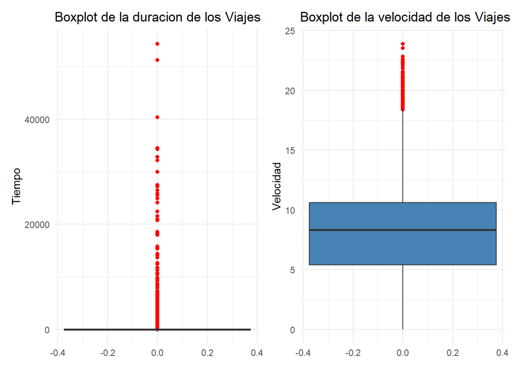

```r
# Boxplot de la duracion de los viajes
p1_tripduration <- ggplot(df_susceptibles_fallo, aes(y = tripduration)) +
  geom_boxplot(fill="steelblue", outlier.color="red") +
  labs(title="Boxplot de la duracion de los Viajes", y="Tiempo") +
  theme_minimal()

# Boxplot de la velocidad de los viajes
p2_speed <- ggplot(df_susceptibles_fallo, aes(y = speed)) +
  geom_boxplot(fill="steelblue", outlier.color="red") +
  labs(title="Boxplot de la velocidad de los Viajes", y="Velocidad") +
  theme_minimal()

(p1_tripduration | p2_speed)
```

Tras el análisis de los datos, se observa la presencia de un elevado número de valores atípicos en la variable de duración de los viajes. Por este motivo, se ha decidido establecer un límite máximo de 75 minutos, al considerar que este es el tiempo máximo razonable que un usuario podría tardar en completar un trayecto, incluso en el caso de que la bicicleta presentase algún tipo de avería. Este valor se ha revisado analizando en google maps el tiempo del viaje que estima esta aplicación al ir entre las dos estaciones más distantes de nuestro dataset. Este valor está en torno a 45 minutos, decidiendo por nuestra parte añadir media hora más para no perder datos sensibles.

En cuanto a las velocidades registradas, se ha comprobado que los valores máximos observados son consistentes con velocidades reales alcanzables por un ciclista. Por lo tanto, en este caso no se considera necesario eliminar ninguna instancia en función de la variable de velocidad.

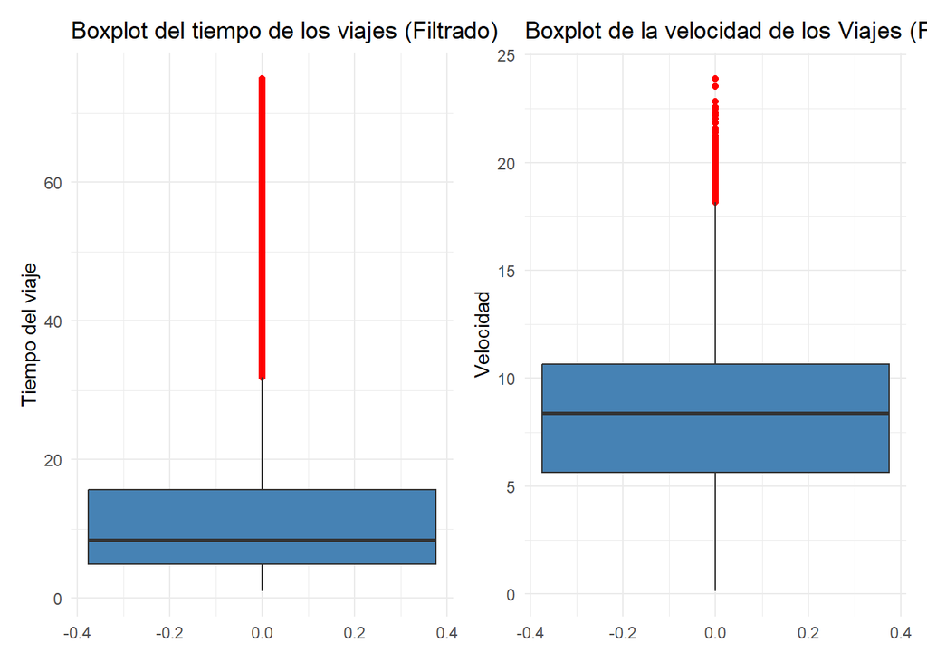

```r
df_susceptibles_fallo <- df_susceptibles_fallo %>% filter(tripduration<=75)

# Boxplot de la duracion de los viajes
p1_tripduration_filtrado <- ggplot(df_susceptibles_fallo, aes(y = tripduration)) +
  geom_boxplot(fill="steelblue", outlier.color="red") +
  labs(title="Boxplot del tiempo de los viajes (Filtrado)", y="Tiempo del viaje") +
  theme_minimal()

# Boxplot de la velocidad de los viajes
p2_speed_filtrado <- ggplot(df_susceptibles_fallo, aes(y = speed)) +
  geom_boxplot(fill="steelblue", outlier.color="red") +
  labs(title="Boxplot de la velocidad de los Viajes (Filtrado)", y="Velocidad") +
  theme_minimal()

(p1_tripduration_filtrado | p2_speed_filtrado)
```

### 5.2.1. Agrupación de datos por bicicleta

Una vez eliminadas todas las instancias de trayectos que puedan afectar a nuestro análisis se ha procedido a la creación de un dataset que agrupe los datos preprocesados por bike_id, de forma que obtengamos un dataset en el que cada instancia sea una bicicleta y que tenga los siguientes atributos:

1. **bikeid**
   - Identificador único de cada bicicleta
2. **velocidad_media**
   - Velocidad media a la que ha ido cada bicicleta (km/h).
3. **ultima_vez_utilizada**
   - Fecha y hora de la última vez que se utilizó cada bicicleta.
4. **primera_vez_utilizada**
   - Fecha y hora de la primera vez que se utilizó cada bicicleta.
5. **km_totales**
   - Distancia total recorrida por cada bicicleta (km).
6. **distancia_media_por_dia**:
   - Distancia media recorrida por cada bicicleta por día.
7. **veces_utilizada**:
   - Número de veces que se ha utilizado cada bicicleta.
8. **dias_uso**:
   - Número de días entre primera_vez_utilizada y ultima_vez_utilizada.
9. **media_usos_por_dia**
   - Media de usos de cada bicicleta por día.

```r
df_bikes <- df_susceptibles_fallo %>%
  group_by(bikeid) %>%
  summarise(
    velocidad_media = mean(speed, na.rm = TRUE),
    ultima_vez_utilizada = max(starttime, na.rm = TRUE),
    primera_vez_utilizada = min(starttime, na.rm = TRUE),
    km_totales = sum(distance_km, na.rm = TRUE),
    distancia_media_por_dia = mean(distance_km / as.numeric(difftime(max(starttime), min(starttime), units="days") + 1), na.rm = TRUE),
    veces_utilizada = n(),
    dias_uso = as.numeric(difftime(ultima_vez_utilizada, primera_vez_utilizada, units="days")) + 1,
    media_usos_por_dia = veces_utilizada / dias_uso
  )
```

```r
df_bikes_not_used <- df_bikes %>% filter(ultima_vez_utilizada > as.Date("2020-11-01"))
df_bikes_used <- df_bikes %>% filter(ultima_vez_utilizada <= as.Date("2020-11-01"))
```

### 5.2.1. Obtención de datos para realizar Clustering

- Velocidad media baja: podría indicar que la bicicleta presenta algún defecto mecánico que impide al usuario circular a una velocidad normal.
- Distancia media recorrida baja: podría ser señal de que los usuarios detectan un problema al inicio del trayecto y deciden devolver la bicicleta rápidamente.
- Media de usos por día baja: una baja frecuencia de uso puede sugerir que los usuarios evitan dicha bicicleta por considerar que presenta algún tipo de fallo.

Por todo ello, se construirá un nuevo dataframe que contendrá exclusivamente estas variables clave, sobre el cual se aplicará el proceso de clustering para determinar diferentes niveles de prioridad en la revisión de las bicicletas.

```r
datos_cluster <- df_bikes_used %>%
  select(velocidad_media, distancia_media_por_dia, media_usos_por_dia)

datos_cluster <- scale(datos_cluster)
```

### 5.2.1. Método del Codo y Clustering

A continuación, se aplica el método del codo para determinar el número óptimo de clusters en el análisis de clustering.

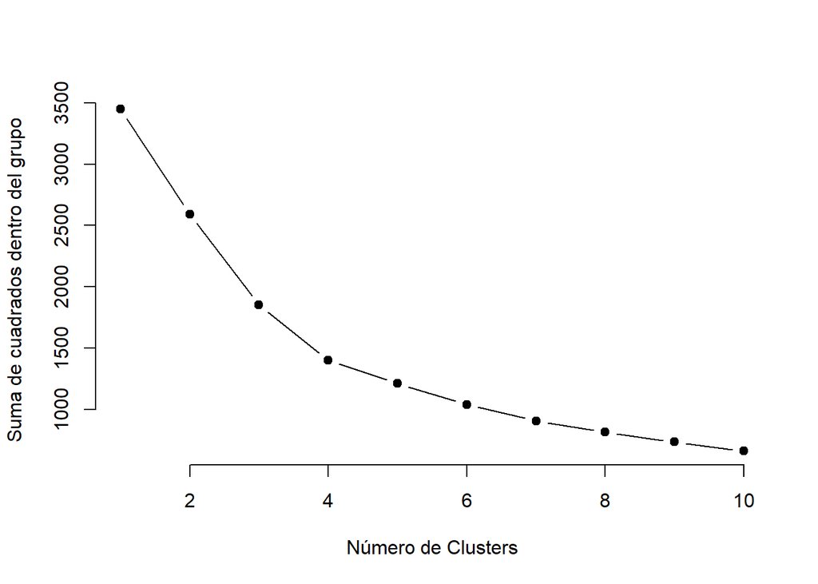

```r
set.seed(123)
wss <- sapply(1:10, function(k){
  kmeans(datos_cluster, centers = k, nstart = 10)$tot.withinss
})

plot(1:10, wss, type="b", pch = 19, frame = FALSE,
     xlab="Número de Clusters", ylab="Suma de cuadrados dentro del grupo")
```

Tal y como se observa en la gráfica, el punto en el que la curva comienza a aplanarse indica el número óptimo de clusters, que en este caso es 4.

Para finalizar, se ha decidido utilizar la técnica de clustering K-Means con 4 clusters para agrupar las bicicletas según sus características de uso. Se utilizan las variables velocidad media, distancia media recorrida por día y media de usos por día para segmentarlas en grupos con comportamientos similares.

```r
set.seed(123)
kmeans_result <- kmeans(datos_cluster, centers = 4, nstart = 10)

df_bikes_used$cluster <- as.factor(kmeans_result$cluster)

plot_ly(df_bikes_used,
        x = ~velocidad_media,
        y = ~distancia_media_por_dia,
        z = ~media_usos_por_dia,
        color = ~cluster,
        colors = "Set1",
        type = "scatter3d",
        mode = "markers") %>%
  layout(title = "Clustering de Bicicletas en 3D",
         scene = list(xaxis = list(title = "Velocidad Media"),
                      yaxis = list(title = "Distancia Media por Día"),
                      zaxis = list(title = "Media Usos por Día")))
```

[interactive chart not shown]

### Conclusiones

Tras la realización del análisis propuesto, se han obtenido varias agrupaciones que permiten clasificar las bicicletas en función de su probabilidad de presentar algún tipo de problema. Esta clasificación ha servido para establecer un sistema de prioridades en el mantenimiento de la flota, ordenando las bicicletas desde aquellas que requieren una revisión urgente hasta las que presentan un menor riesgo de incidencia.

Para ello, se han definido cinco categorías de prioridad: ‘Muy alta’, ‘Alta’, ‘Media’, ‘Baja’ y ‘Muy baja’, con los siguientes criterios de asignación:

```r
df_prioridades_revision <- bind_rows(
  df_bikes_not_used %>%
    transmute(bikeid, prioridad = "Muy alta"),

  df_bikes_used %>%
    transmute(bikeid,
              prioridad = case_when(
                cluster == "1" ~ "Alta",
                cluster == "2" ~ "Media",
                cluster == "4" ~ "Baja",
                cluster == "3" ~ "Muy baja"
              ))
)

str(df_prioridades_revision)
```

```
## tibble [1,858 × 2] (S3: tbl_df/tbl/data.frame)
##  $ bikeid   : int [1:1858] 14536 14585 14598 14607 14639 14657 14729 15049 15268 15348 ...
##  $ prioridad: chr [1:1858] "Muy alta" "Muy alta" "Muy alta" "Muy alta" ...
```